# Genoma_Sporosarcina_luteola_UB5

CFG

19/11/2021

### Resumen

El género de Sporosarcina pertenece al phylum firmicutes y a la familia planococaceae, incluye bacterias no patógenas, gram positivas, formadoras de esporas con un genoma promedio de 3.3 Mb (Kluyver y van Neil, 1936; Oliver et al., 2018). Se ha demostrado recientemente que S. luteola UB5, la cual fue aislada de jales mineros alcalinos en la región minera de Taxco, posee una elevada actividad ureasa y es tolerante a altas concentraciones de elementos toxicos como (As, Cd, Pb, Cu y Zn). Además, UB5 es capaz de inducir la formación in vitro de biominerales como calcita y vaterita y otros carbonatos metálicos como rodocrosita MnCO3, cerusita PbCO3, otavita CdCO3, estroncianita SrCO3, hidrocincita (Zn5(CO3)2 (OH)6), witherita BaCO3 e hidromagnesita Mg5(CO3) 4 (OH)2 ·4H2O (Cuaxinque-Flores et al., 2020). Sin embargo, hay poca información a nivel genomico de este género de bacterias y es por ello que resulta interesante conocer los mecanismos que le permiten a esta bacteria interactuar con los diferentes metales y precipitarlos como fases minerales termodinamicamente estables

### Objetivos

El objetivo de este proyecto fue secuenciar y analizar la calidad de las secuencias con fastqc y trimmomatic

### Estructura de la carpeta

Antes de iniciar con la descarga de los datos de secuenciación se crearon los directorios para almacenar los archivos en Destoktop

Para ello nos posicionamos en nuestro directorio Desktop utilizamos el comando mkdir y creamos el directorio Data para almacenar los archivos de del genoma de S. luteola UB5 y creamos el directorio de Rmarkdown para el reporte en .html del proyecto **$ mkdir data**  
**$ cd data** **$ mkdir Rmarkdown**

Posteriormente, se obtuvieron los datos de un secuenciador de próxima generación (Next Generation Sequencing;NGS) mediante la plataforma de illumina novaseq 6000 de lecturas pareadas, con una longitud de 101

### Obtencion de datos de NGS por Illumina

El primer paso de este apartado fue descargar los archivos de secuenciación de Illumina Novaseq 6000, para ello utilizamos el siguiente comando, pero antes nos posicionamos dentro del directorio data

**$ wget https://data.macrogen.com/~macro3/HiSeq02//20190605/HN00107806/UB5_1.fastq.gz**  
**$ wget https://data.macrogen.com/~macro3/HiSeq02//20190605/HN00107806/UB5_2.fastq.gz**

### Cargar datos al servidor

Posteriormente carge los datos al servidor utilizando la aplicación de FTP libre Filezilla

Dentro del directorio /home/alumno08/ cree un directorio nuevo para mis datos de secuenciación denominado ub5_genome **mkdir ub5_genome** Dentro del directorio /home/alumno08/ub5_genome se cargaron los archivos de secuenciación con lecturas pareadas y se denominan como  
UB5_1.fastq.gz UB5_2.fastq.gz

Con el comando gunzip vamos a descomprimir los archivos de NGS  
**$ gunzip UB5_1.fastq.gz UB5_2.fastq.gz**

Listamos el directorio con ls para checar que los archivos se descomprimieron y nos regresa los siguientes archivos  
**UB5_1.fastq UB5_2.fastq**

### Comandos para visualizar y explorar los archivos descomprimidos

Con el comando file nos indica el formato de nuestro archivo  
**$ file UB5_1.fastq UB5_2.fastq**  
**UB5_1.fastq: ASCII text**  
**UB5_2.fastq: ASCII text**

Con el comando ls -l podemos obtener una vista detallada de nuestros archivos  
**$ rw-r–r–. 1 alumno08 alumnos 2102561916 Nov 15 19:14 UB5_1.fastq** **$ rw-r–r–. 1 alumno08 alumnos 2102561916 Nov 15 19:14 UB5_2.fastq**

Con el comando wc -l nos indica el numero de filas totales en nuestro archivo de secuenciación **$ wc -l UB5_1.fastq UB5_2.fastq** 31210516 UB5_1.fastq  
31210516 UB5_2.fastq  
62421032 total

Con el comando head -n4 vamos a visualizar el encabezado de nuestros archivos que descomprimimos anteriormente **$ head -n4 UB5_1.fastq UB5_2.fastq**

Este comando nos muestra las primeras 4 lineas de nuestros archivos de secuenciación

==> UB5_1.fastq <==  
@A00721:57:HLFV7DSXX:1:1101:8603:1016 **1**:N:0:GTGTCGGA+GCTTGCGC GNGAGGGGAATTGAATGATGAACGCTTACGATGAATATATGAAAAGTATCGTGAAACCGATGCGTGAAGAACTTGTTCAAACGGGCTTCACAGAACTTACG  
+  
F#FFFFFFF:FFFFFFFFFFFFFFFFFFFFFFFFFFFFFFFFFFFFFFFFFFFFFFFFFFFFFFFFFFFFFFFFFFFFFFFFFFFFFFFFFFFFFFFFFFF

==> UB5_2.fastq <==  
@A00721:57:HLFV7DSXX:1:1101:8603:1016 **2**:N:0:GTGTCGGA+GCTTGCGC AAATTGCAATTGATGGCGAGCTCGGTGGAACTTCAGGGAAAAAGCTTCTCATCTTCTCTGTCGCTTCTTTATCTTGACCTGCAAATACAGTAAATAAATGT  
+ FFFFFFFFFFFFFFFFFFFFFFFFFFFFFFFFFFFFFFFFF:FFFFFFFFFFFFFFFFFFFFFFF,F:FFFFFFFFF:FFFFFFFFFFFFFFFFFFFFFFF

Esto fue útil para observar las características de nuestros archivos de secuenciación, nos da el id de cada secuencia, la secuencia, el separador (+) y su calidad de estas secuencias en formato ASCII

**- Quality encoding:!“#$%&’()*+,-./0123456789:;<=>?@ABCDEFGHIJ **| | | | |** Quality score: 01……..11……..21……..31……..41**

Comparando nuestros archivos con la tabla anterior, podemos darnos cuenta que nuestros archivos de NGS tienen una calidad aproximada de **36** en formato phred

Además podemos utilizar el comando tail para ver las últimas filas de nuestros archivos de NGS  
**$ tail -n4 UB5_1.fastq UB5_2.fastq**

==> UB5_1.fastq <== @A00721:57:HLFV7DSXX:1:2678:27353:37059 1:N:0:GTGTCGGA+GCTTGCGC CGAGCGCAGTATCTGCTTTACGAATAGCAGTACGCATTGCTGCTTTGTACATTGAGTTTTGCTCATTCGCAGCGGCGCTTTGTTTAACGCGCTTAATTGCA + FFFFFFFFFFFFFFFFFFFFFFFFFFFFFFFFFFFFFFFFFFF::FFFFF:FFFFF,FFFFFFFFFFFFFFFFFFFFF,FFFF:FFFFFFFFFFFFFFFFF

==> UB5_2.fastq <== @A00721:57:HLFV7DSXX:1:2678:27353:37059 2:N:0:GTGTCGGA+GCTTGCGC ATTCTTTCTTCCCCTTCAGCATTAATTTTGACAGATGTCAAAATTACTCTGCCTTTTCGTTGCTCATCAAATTGTATACCTTCAGATTGCTTTAATTTCTG + FFFFFFFF:FFFFF:FFFFFF,FFF:FFF:FFFFFFFFFFFFFF,FF:F:FFFF,FFF,,FFFFFFF:FFFFFFFFFFFFFFFFFFFFFF:FFFFFFF,FF

### Vamos a crear el directorio data y untrimmed fastq para mover los archivos

**$ mkdir -p ~/home/alumno08/ub5_genome/data/untrimmed_fastq**

Posteriormente moví los archivos .fastq al directorio data, para ello, me posicione en el directorio data/untrimmed_fastq y ejecute el siguiente comando  
**$ cp /home/alumno08/ub5_genome fastq/*.fastq .**

Con el comando less vemos nuestro archivo y posteriormente vamos a checar cuantas lecturas tenemos en cada uno de nuestros archivos de secuenciación  
**$ grep -c “@A00721” UB5_1.fastq UB5_2.fastq** y el resultado fue el siguiente  
UB5_1.fastq:7802629  
UB5_2.fastq:7802629

Ahora el siguiente paso es correr el análisis de calidad con fastqc, para ello nos posicionamos en el directorio untrimmed_fastqc y ejecutamos el siguiente comando

$ fastqc *.fastq*

Como resultado nos arroja los siguientes archivos, listamos con ls -lh

**drwxr-xr-x. 4 alumno08 alumnos 118 Nov 16 08:59 UB5_1_fastqc** **-rw-r–r–. 1 alumno08 alumnos 559K Nov 16 08:59 UB5_1_fastqc.html** **-rw-r–r–. 1 alumno08 alumnos 919K Nov 16 08:59 UB5_1_fastqc.zip** **drwxr-xr-x. 4 alumno08 alumnos 118 Nov 16 08:59 UB5_2_fastqc** **-rw-r–r–. 1 alumno08 alumnos 581K Nov 16 09:00 UB5_2_fastqc.html** **-rw-r–r–. 1 alumno08 alumnos 952K Nov 16 09:00 UB5_2_fastqc.zip**

### Crear el directorio de resultados, para mover los archivos en formato .html y los archivos .zip

**$ mkdir -p /home/alumno08/ub5_genome/results/untrimmed_fastq** **$ mv *.zip /home/alumno08/ub5_genome/results/untrimmed_fastq $ mv* .html /home/alumno08/ub5_genome/results/untrimmed_fastq**

Comando para mover los archivos html a Desktop/untrimmed_fastqc  
Posteriormente copie los archivos html y .zip a mi Desktop local para visualizarlos correctamente, para ello utilice el comando que se muestra a continuación

**$ scp -r alumno08@10.147.17.33:/home/alumno08/ub5_genome/results/untrimmed_fastq/*.html /Users_html alumno08@10.147.17.33’s password:**  
Posteriormente liste con ls -lha para ver mas a detalle cada archivo

**UB5_1_fastqc.html 100% 558KB 2.8MB/s 00:00** **UB5_2_fastqc.html 100% 581KB 1.5MB/s 00:00**

Comando para mover los archivos .zip a Desktop/untrimmed_fastqc  
**$ scp -r alumno08@10.147.17.33:/home/alumno08/ub5_genome/results/untrimmed_fastq/*.zip /Users_html**  
**alumno08@10.147.17.33’s password:**  
**UB5_1_fastqc.zip 100% 918KB 806.9KB/s 00:01**  
**UB5_2_fastqc.zip 100% 951KB 765.4KB/s 00:01**

### Visualización del archivo UB5_1.fastqc.html

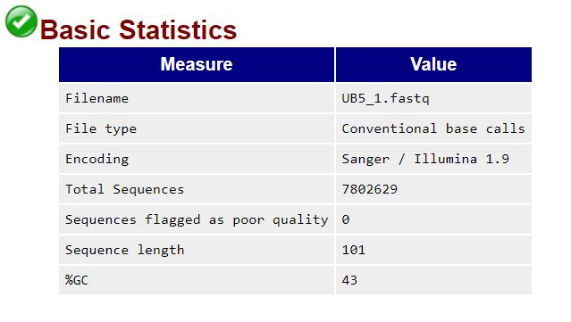

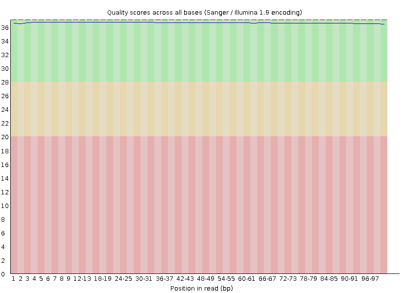

### Visualización del archivo UB5_2.fastqc.html

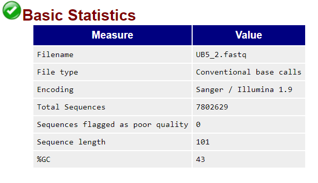

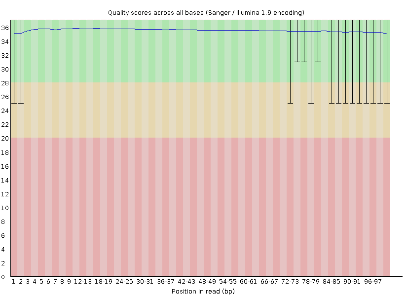

### Trimming and filtering

Para descomprimir los archivos lo hice con el siguiente loop

$ for file name in *.zip  
$ do  
$ unzip $filename  
$ done

Posteriormente uno los archivos .txt para ver cuales de los archivos de secuenciación fallaron en algún análisis de calidad  
**$ cat */summary.txt > fastqc_summary.txt**  
Observamos el archivo con el comando less para ver en cual prueba del análisis fastqc fallaron las muestras

**less fastqc_summary.txt**

PASS Basic Statistics UB5_1.fastq  
PASS Per base sequence quality UB5_1.fastq  
PASS Per tile sequence quality UB5_1.fastq  
PASS Per sequence quality scores UB5_1.fastq  
PASS Per base sequence content UB5_1.fastq  
PASS Per sequence GC content UB5_1.fastq  
PASS Per base N content UB5_1.fastq  
PASS Sequence Length Distribution UB5_1.fastq  
**WARN Sequence Duplication Levels UB5_1.fastq**  
PASS Overrepresented sequences UB5_1.fastq PASS Adapter Content UB5_1.fastq  
PASS Basic Statistics UB5_2.fastq  
PASS Per base sequence quality UB5_2.fastq  
PASS Per tile sequence quality UB5_2.fastq  
PASS Per sequence quality scores UB5_2.fastq  
PASS Per base sequence content UB5_2.fastq  
PASS Per sequence GC content UB5_2.fastq  
PASS Per base N content UB5_2.fastq  
PASS Sequence Length Distribution UB5_2.fastq  
**WARN Sequence Duplication Levels UB5_2.fastq**  
PASS Overrepresented sequences UB5_2.fastq  
PASS Adapter Content UB5_2.fastq

Movemos el archivo Nextera a nuestro directorio de untrimed_fastqc para hacer el trimming  
Para ello utilizamos el comando siguiente  
**$ cp /home/alumno08/dc_workshop/data/untrimmed_fastq/NexteraPE-PE.fa .**

### Correr el programa trimmomatic con los parametros por default

**$ trimmomatic PE UB5_1.fastq UB5_2.fastq UB5_1.trim.fastq.gz UB5_1un.trim.fastq.gz UB5_2.trim.fastq.gz UB5_2un.trim.fastq.gz SLIDINGWINDOW:4:20 MINLEN:25 ILLUMINACLIP:NexteraPE-PE.fa:2:40:15**

TrimmomaticPE: Started with arguments: UB5_1.fastq UB5_2.fastq UB5_1.trim.fastq.gz UB5_1un.trim.fastq.gz UB5_2.trim.fastq.gz UB5_2un.trim.fastq.gz SLIDINGWINDOW:4:20 MINLEN:25 ILLUMINACLIP:NexteraPE-PE.fa:2:40:15

Using PrefixPair: ‘AGATGTGTATAAGAGACAG’ and ‘AGATGTGTATAAGAGACAG’  
Using Long Clipping Sequence: ‘GTCTCGTGGGCTCGGAGATGTGTATAAGAGACAG’  
Using Long Clipping Sequence: ‘TCGTCGGCAGCGTCAGATGTGTATAAGAGACAG’  
Using Long Clipping Sequence: ‘CTGTCTCTTATACACATCTCCGAGCCCACGAGAC’  
Using Long Clipping Sequence: ‘CTGTCTCTTATACACATCTGACGCTGCCGACGA’

ILLUMINACLIP: Using 1 prefix pairs, 4 forward/reverse sequences, 0 forward only sequences, 0 reverse only sequences  
Quality encoding detected as phred33  
Input Read Pairs: 7802629 Both Surviving: 7763165 (**99.49%**) Forward Only Surviving: 34858 (0.45%) Reverse Only Surviving: 4545 (0.06%) Dropped: 61 (0.00%)  
TrimmomaticPE: Completed successfully

Listamos con el comando ls -lah para una vista detallada de los archivos  
**$ ls -lah**  
total 4.7G  
drwxr-xr-x. 2 alumno08 alumnos 179 Nov 16 22:17 .  
drwxr-xr-x. 3 alumno08 alumnos 29 Nov 15 20:23 .. -rw-r–r–. 1 alumno08 alumnos 240 Nov 16 21:57 NexteraPE-PE.fa  
-rw-r–r–. 1 alumno08 alumnos 2.0G Nov 15 19:14 UB5_1.fastq  
-rw-r–r–. 1 alumno08 alumnos 356M Nov 16 23:46 UB5_1.trim.fastq.gz  
-rw-r–r–. 1 alumno08 alumnos 1.8M Nov 16 23:46 UB5_1un.trim.fastq.gz  
-rw-r–r–. 1 alumno08 alumnos 2.0G Nov 15 19:14 UB5_2.fastq  
-rw-r–r–. 1 alumno08 alumnos 407M Nov 16 23:46 UB5_2.trim.fastq.gz  
-rw-r–r–. 1 alumno08 alumnos 279K Nov 16 23:46 UB5_2un.trim.fastq.gz

Cuantas lecturas quedaron después del correr trimmomatic

$ zgrep -c “@A00721” UB5*  
UB5_1.fastq.gz:**7802629**  
UB5_1.trim.fastq.gz:**7763165**  
UB5_1un.trim.fastq.gz:34858  
UB5_2.fastq:**7802629**  
UB5_2.trim.fastq.gz:**7763165**  
UB5_2un.trim.fastq.gz:4545